# Notes for Perry

```r
library(here)
library(tidyverse)
```

```r
litterduff_data =
  readRDS(here::here('02-data',
                     '02-for_analysis',
                     'litterduff_data.rds'))

fwd1h_data =
  readRDS(here::here('02-data',
                     '02-for_analysis',
                     'fwd1h_data.rds'))

fwd10h_data =
  readRDS(here::here('02-data',
                     '02-for_analysis',
                     'fwd10h_data.rds'))

fwd100h_data =
  readRDS(here::here('02-data',
                     '02-for_analysis',
                     'fwd100h_data.rds'))

burn_units =
  readRDS(here::here('02-data',
                     '02-for_analysis',
                     'burn_units.rds'))

plot_centers =
  readRDS(here::here('02-data',
                     '02-for_analysis',
                     'plot_centers.rds'))
```

# Context

**Big picture:**

- Wildland fuels are the combustible biomass that fuels wildland fires. Fuels are often divided into several types of “fuel components” (e.g. duff, litter, fine woody debris, coarse woody debris, understory vegetation, canopy fuels).
- Current operational (i.e., useful for predicting fires in real time) fire models ignore fine-scale heterogeneity in fuel conditions, and predict fire behavior using basic summary statistics (e.g. mean biomass per area) for the modeled area (often a 30x30m pixel). Computational fluid dynamics models are fire models that do include fine-scale heterogeneity in fuel conditions and atmosphere/fire feedbacks, but run slower than real time and so are useful mostly for research.
- Research and theory suggest that fine-scale heterogeneity in fuel conditions does affect fire behavior at coarser scales
- We’ve been funded by the Pyregence consortium to develop a system for sampling and describing fuel conditions that will supply input data for a new fire model in development by researchers at the US Forest Service. The new model is to incorporate fine-scale heterogeneity in fuel conditions, among other innovations.
- The ultimate goal is to develop a system for field sampling and data analysis that will capture information about the fine-scale spatial distribution of combustible biomass to enable realistic predictions of wildfire behavior.
- Ideally, we would like to accomplish this goal by developing spatially-explicit statistical models for different fuel components (e.g. litter, woody debris, understory vegetation). By defining a common statistical model and allowing the parameters to vary by ecosystem, we could generate simulated fuelbeds with realistic spatial properties for input into the fire model. A parametric statistical model also opens up avenues for research, such as comparisons among ecosystems.
- As a fallback, the sampling design is intended to allow for directly using the observed data to map fuel conditions at a fine scale. We could plug the observed data into the fire model directly, skipping the statistical analysis and simulation steps. This may be necessary for some fuel components which are difficult to model well. In a mixture of the two approaches, kriging would be used to fill the spatial gaps between observations for some fuel components.

**This paper:**

- I’m also interested in the fine-scale spatial pattern of biomass as an important and understudied axis of forest structure. Fire is an important ecological process in the ecosystem I study (Californian mixed conifer forests), and research shows that fire alters the loading (amount) of biomass of several fuel components. My hypothesis is that fire will also alter the fine-scale spatial distribution of biomass.
- We used a prescribed fire study happening and Blodgett Forest Research Station as a test-bed for the sampling protocol and spatial statistical analysis we’re delivering for the pyregence grant. By sampling and describing the fine-scale spatial pattern of fuels before and after a prescribed fire treatment, we can also test whether the prescribed fire affects the fine-scale spatial pattern.
- This paper will focus on litter/duff and fine woody debris (FWD), which are the fuel components most strongly affected by prescribed fires and the easiest to model.

# Data collection

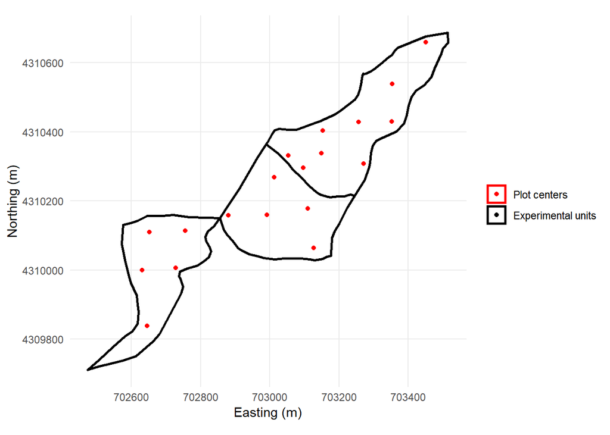

- On each plot:
  - The depth of litter and duff was measured (to nearest 0.5 cm) at 64 predetermined subsample locations.
  - FWD particles (in 3 size classes) intersecting a 1m subtransect were counted at 32 predetermined subsample locations.
- The spatial arrangements of subsample locations within each plot were designed to get good coverage of pairwise distances between subsamples in the range 0.1m - 60m for litter/duff and the range 1m-60m for FWD. Variogram analysis from other forest and rangeland ecosystems in the western US suggests that most spatial correlation is within a distance of ~1m for litter/duff and within ~5m for FWD. Here are histograms of the pairwise distances for a single plot:

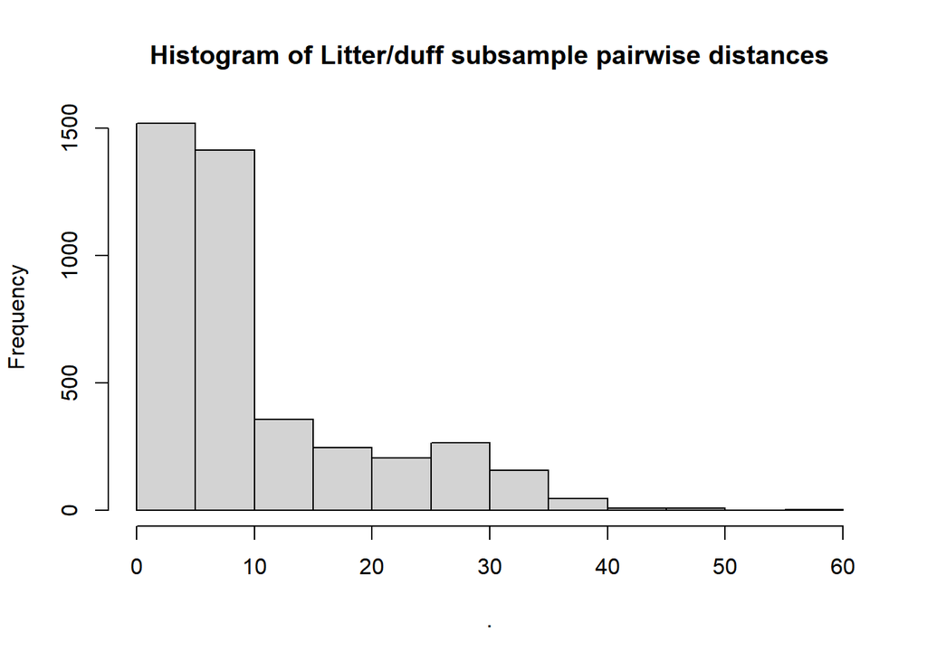

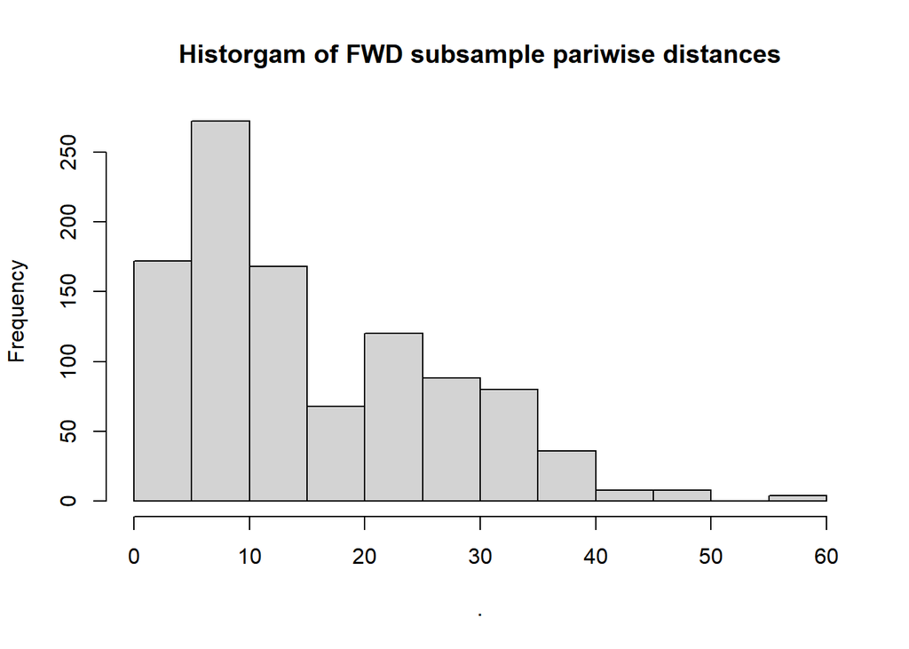

- Fuels were inventoried both before and after prescribed burns of the three experimental units. The three burns took place on separate days.

# Data exploration

## Litter and duff

Histogram of litter+duff depths, rounded to the nearest cm:

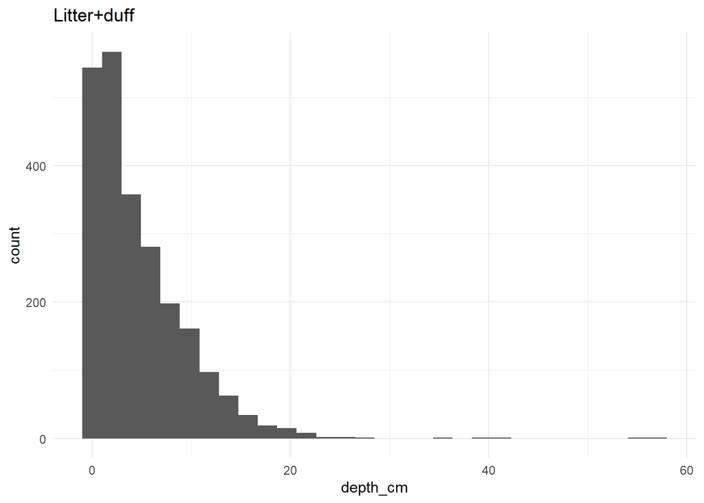

```r
litterduff_data$X %>%
  as_tibble() %>%
  mutate(depth_cm = litterduff_data$Y) %>%
  ggplot(aes(x = depth_cm))+
  geom_histogram()+
  theme_minimal()+
  labs(title = 'Litter+duff')
```

Boxplot crossing timestep (pre/post burn) with experimental unit (A, B, or C):

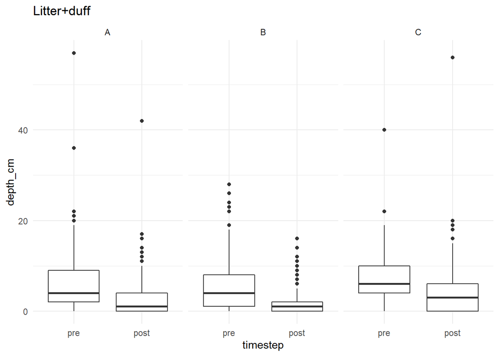

```r
litterduff_data$X %>%
  as_tibble() %>%
  mutate(depth_cm = litterduff_data$Y,
         timestep =
           factor(ifelse(timePost==0,'pre', 'post'),
                  levels = c('pre', 'post')),
         comp = ifelse(compB==0&compC==0,
                       'A',
                       ifelse(compB==1,
                              'B',
                              'C'))) %>%
  ggplot(aes(x = timestep, y = depth_cm))+
  geom_boxplot()+
  facet_wrap(~comp, nrow = 1)+
  theme_minimal()+
  labs(title = 'Litter+duff')
```

## FWD: 1-hour

1-hour fuels are FWD particles with diameters from 0-0.64cm.

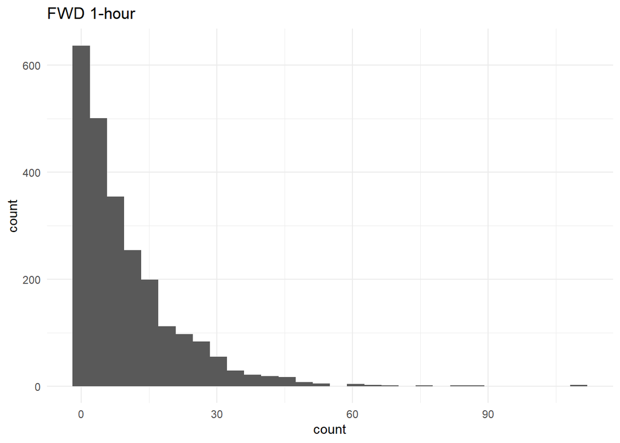

```r
fwd1h_data$X %>%
  as_tibble() %>%
  mutate(count = fwd1h_data$Y) %>%
  ggplot(aes(x = count))+
  geom_histogram()+
  theme_minimal()+
  labs(title = 'FWD 1-hour')
```

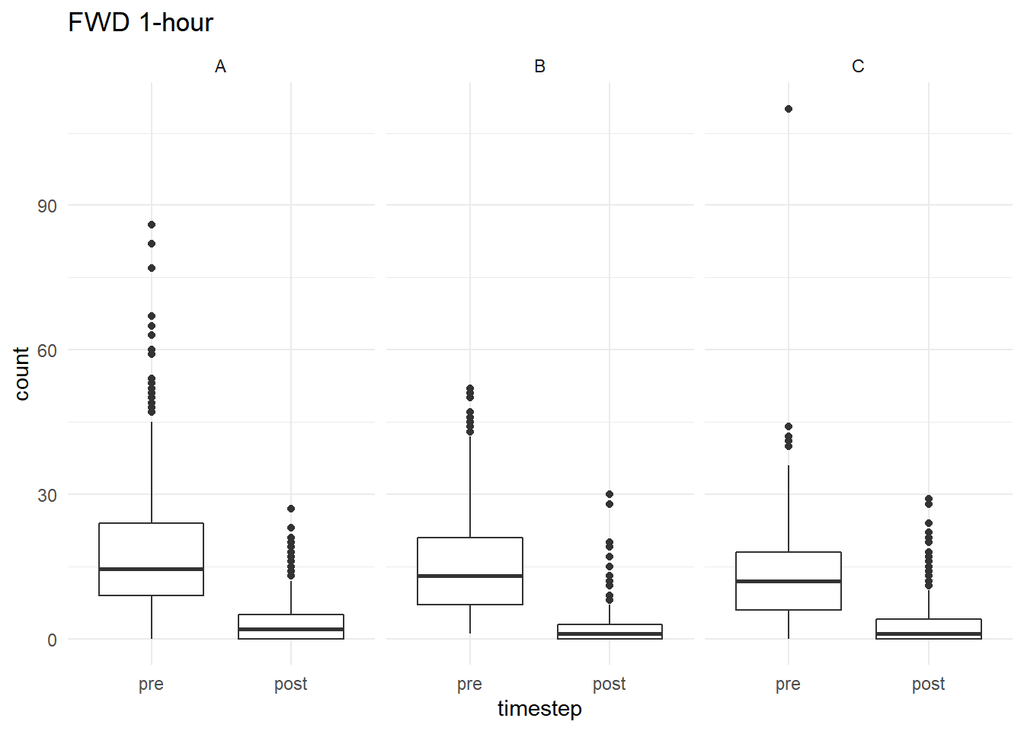

```r
fwd1h_data$X %>%
  as_tibble() %>%
  mutate(count = fwd1h_data$Y,
         timestep =
           factor(ifelse(timePost==0,'pre', 'post'),
                  levels = c('pre', 'post')),
         comp = ifelse(compB==0&compC==0,
                       'A',
                       ifelse(compB==1,
                              'B',
                              'C'))) %>%
  ggplot(aes(y = count, x = timestep))+
  geom_boxplot()+
  facet_wrap(~comp, nrow = 1)+
  theme_minimal()+
  labs(title = 'FWD 1-hour')
```

## FWD: 10-hour

10-hour fuels are FWD particles with diameters from 0.64-2.54 cm.

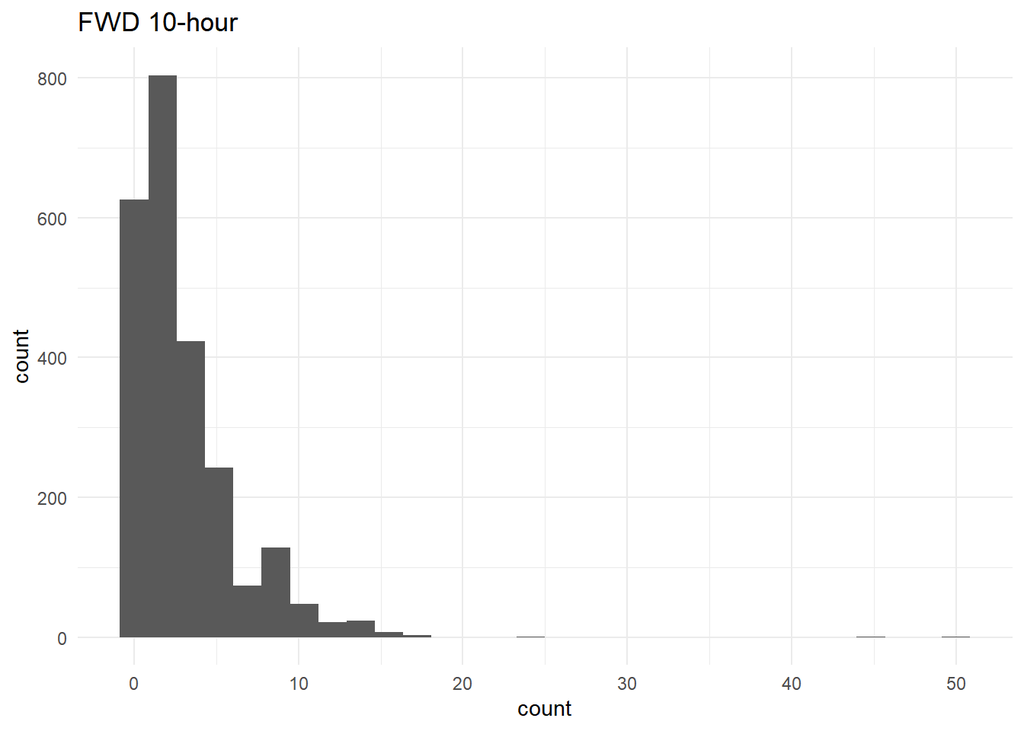

```r
fwd10h_data$X %>%
  as_tibble() %>%
  mutate(count = fwd10h_data$Y) %>%
  ggplot(aes(x = count))+
  geom_histogram()+
  theme_minimal()+
  labs(title = 'FWD 10-hour')
```

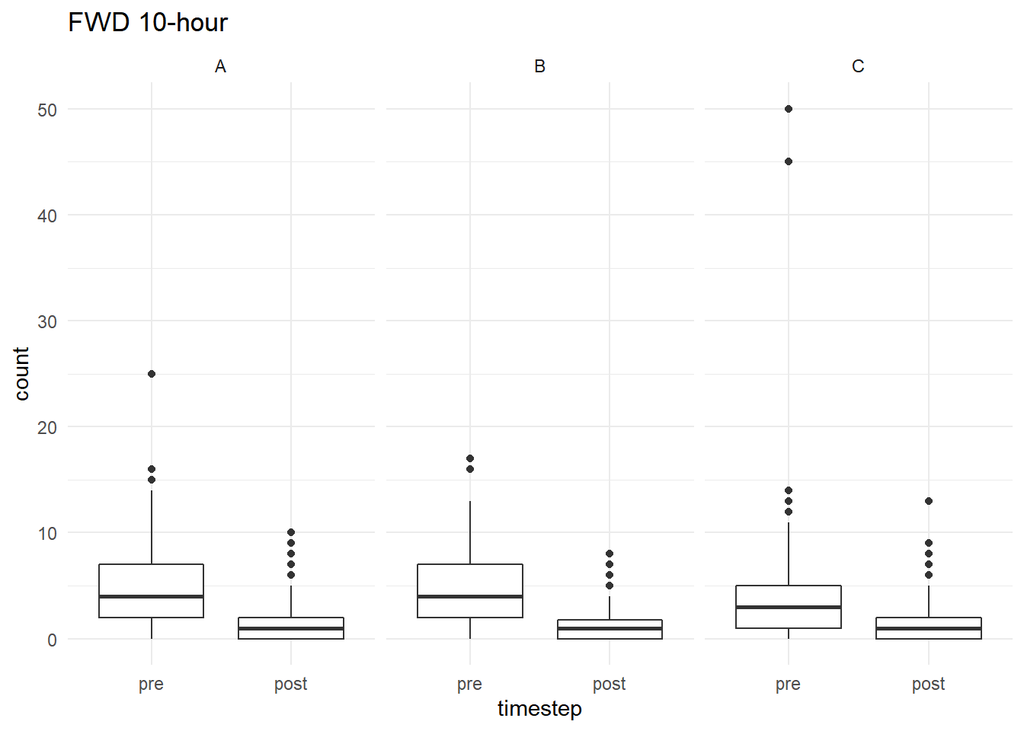

```r
fwd10h_data$X %>%
  as_tibble() %>%
  mutate(count = fwd10h_data$Y,
         timestep =
           factor(ifelse(timePost==0,'pre', 'post'),
                  levels = c('pre', 'post')),
         comp = ifelse(compB==0&compC==0,
                       'A',
                       ifelse(compB==1,
                              'B',
                              'C'))) %>%
  ggplot(aes(y = count, x = timestep))+
  geom_boxplot()+
  facet_wrap(~comp, nrow = 1)+
  theme_minimal()+
  labs(title = 'FWD 10-hour')
```

## FWD: 100-hour

100-hour fuels are FWD particles with diameters from 2.54-7.62 cm.

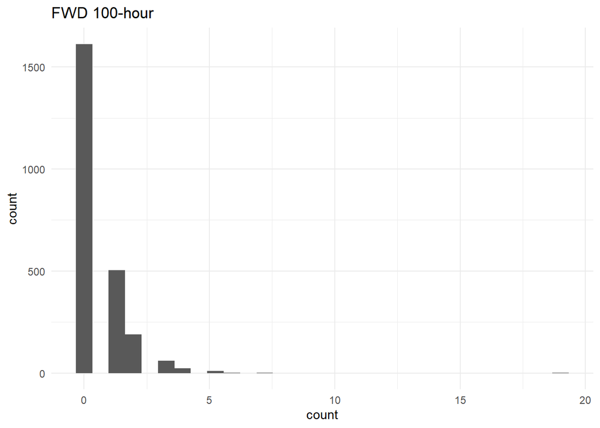

```r
fwd100h_data$X %>%
  as_tibble() %>%
  mutate(count = fwd100h_data$Y) %>%
  ggplot(aes(x = count))+
  geom_histogram()+
  theme_minimal()+
  labs(title = 'FWD 100-hour')
```

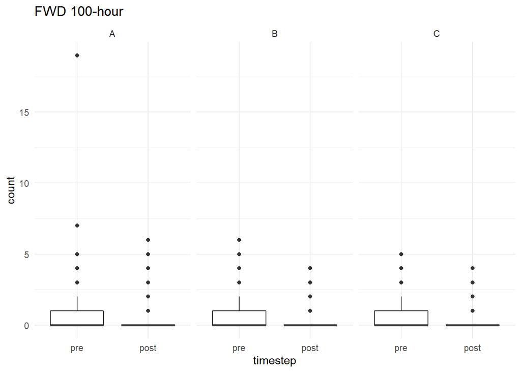

```r
fwd100h_data$X %>%
  as_tibble() %>%
  mutate(count = fwd100h_data$Y,
         timestep =
           factor(ifelse(timePost==0,'pre', 'post'),
                  levels = c('pre', 'post')),
         comp = ifelse(compB==0&compC==0,
                       'A',
                       ifelse(compB==1,
                              'B',
                              'C'))) %>%
  ggplot(aes(y = count, x = timestep))+
  geom_boxplot()+
  facet_wrap(~comp, nrow = 1)+
  theme_minimal()+
  labs(title = 'FWD 100-hour')
```

# Analysis

## Model Descriptions

### Litter+duff depths

The model for litter and/or duff depths is:

$$Y_i \sim \text{NegBinomial}(\mu_i, \kappa)$$

where:

- $Y_i$ is the observed depth of litter and/or duff at observation $i$ in centimeters, rounded to the nearest cm
- $\mu_i$ is the unobserved mean depth at observation $i$
- $\kappa$ is the negative binomial dispersion parameter, here assumed constant across all samples

$$\text{log}(\mu_i) = \textbf{X}_i\beta + \textbf{GPPRE}_{l,p} IPRE_i +
\textbf{GPPOST}_{l,p} IPOST_i +b_{p}$$

where:

- $\textbf{X}_i$ is the *i*th row of the design matrix of fixed effects covariates. The fixed effects covariates are for experimental unit (A, B, or C) crossed with timestep (pre or post), so there are 6 main effects (Intercept = A:Pre, main effect B, main effect C, main effect Post, B:Post, and C:Post).
- $\beta$ are the 6 coefficients for the fixed effects
- $\textbf{GPPRE}$ is an $L\times P$ matrix of realized gaussian process random effects, with $L$ rows for the within-plot spatial locations and $P$ columns for the plots. $l$ is the index of the location for the observation $i$ and $p$ is the index for the plot of of the observation $i$.
- $IPRE_i$ is a dummy variable (1 if true, 0 if false) coding whether observation *i* is from the preburn timestep and controlling whether the pre-burn gaussian process random effect $\textbf{GPPRE}_{l_i,p_i}$ is included in the linear predictor $\mu_i$.
- $\textbf{GPPOST}$ and $IPOST_i$ are likewise the matrix of gaussian process random effects and an indicator variable for the postburn timestep.
- $b$ is a vector of normally distributed random effects for the plots, $b \sim \text{Normal}(0,\sigma_{plot}^2)$, and $b_{p}$ is the random effect for plot $p$, the plot associated with observation $i$.

$$\textbf{GPPRE}_{1:L,p} \sim \text{MVN}(0,\Sigma_{PRE})$$

where:

- $\Sigma_{PRE}$ is the $L$ by $L$ covariance matrix of sample locations within a plot. The gaussian process parameters, and thus the covariance matrix, are constant across plots.

$$\Sigma_{PRE} = \alpha_{PRE}^2 \text{exp}(\frac{-D^2}{2\rho_{PRE}^2})$$

where:

- $\alpha_{PRE}$ is the standard deviation of the gaussian process random effect for the preburn timestep, controlling the magnitude of the spatial effect
- $D^2$ is the $L$ by $L$ matrix of squared distances among all sample locations in a plot
- $\rho_{PRE}$ is the length-scale parameter of the gaussian process random effect the breburn timestep, controlling the rate at which the correlation between observations decays as the distance between them increases

The definitions for $\textbf{GPPOST}$, $\Sigma_{POST}$, $\alpha_{POST}$, and $\rho_{POST}$ are as above.

Stan code for Litter+duff model:

```stan
data {
  int N; // number of observations
  int P; // number of plots
  int L; // number of distinct locations within each plot

  int Y[N]; // observed responses
  int plot_id[N]; // plot IDs
  int location_id[N]; // location IDs

  matrix[N,6] X; // fixed effects design matrix, giving dummy variables for
                 // COMP (A, B, or C) crossed with TIMESTEP (pre and post), with
                 // A:PRE the intercept

  int pre[N]; // indicator 1 if pre 0 if post
  int post[N]; // timestep explanatory variable; 1 if post, 0 otherwise

  vector[2] coords[L]; // plot-relative coordinates of each subsample
}

parameters {
  vector[6] beta; // fixed effect coefficients
  matrix[L,P] zGP_pre; // standard-normal deviates for GP effect prefire
  matrix[L,P] zGP_post; // standard normal deviates for GP effect postfire

  real<lower=0> alpha_pre; // standard deviation of prefire GP
  real<lower=0> rho_pre; // length-scales of prefire GP

  real<lower=0> alpha_post; // standard deviation of postfire GP
  real<lower=0> rho_post; // length-scale of postfire GP

  real<lower=0> sigmaPlot; // standard deviation of plot effect
  vector[P] z_plot; // standard normal deviates for plot effect

  real<lower=0> kappa; // NB dispersion parameter

}

transformed parameters {

  vector[P] plot_effect; // atual plot effects


  plot_effect = sigmaPlot * z_plot;
}

model {
  // variable declarations
  vector[N] logmu; // linear predictor
  matrix[L,P] GP_pre; // actual GP effects for each plot:location
  matrix[L,P] GP_post; // actual GP effects for postfire
  matrix[L,L] K_pre; // covariance matrix for within-plot GP (prefire)
  matrix[L,L] KL_pre; // cholesky decomposition of K_pre
  matrix[L,L] K_post; // covariance matrix for within-plot GP (postfire)
  matrix[L,L] KL_post; // cholesky decomposition of K_post

  // priors
  beta ~ normal(0, 2);
  sigmaPlot ~ normal(0, 0.5);
  kappa ~ cauchy(0,5);
  alpha_pre ~ normal(0, 0.5);
  alpha_post ~ normal(0, 0.5);
  rho_pre ~ inv_gamma(5,40);
  rho_post ~ inv_gamma(5,40);

  // random effect realizations
  z_plot ~ std_normal();
  to_vector(zGP_pre) ~ std_normal();
  to_vector(zGP_post) ~ std_normal();

  // gaussian processse
  K_pre = gp_exp_quad_cov(coords, alpha_pre, rho_pre);
  K_pre = add_diag(K_pre, 1e-9);
  KL_pre = cholesky_decompose(K_pre);
  GP_pre = KL_pre * zGP_pre;

  K_post = gp_exp_quad_cov(coords, alpha_post, rho_post);
  K_post = add_diag(K_post, 1e-9);
  KL_post = cholesky_decompose(K_post);
  GP_post = KL_post * zGP_post;

  // linear predictor
  for (i in 1:N){
    logmu[i] =
      X[i,] * beta +
      GP_pre[location_id[i], plot_id[i]] * pre[i] +
      GP_post[location_id[i], plot_id[i]] * post[i] +
      plot_effect[plot_id[i]];
  }

  // likelihood
  Y ~ neg_binomial_2_log(logmu, kappa);
}
```

### FWD counts

The model for FWD counts is identical to that for litter+duff depths, except that

$$\Sigma_{PRE} = \alpha_{PRE}^2 \text{exp}(\frac{-D^2}{2\rho_{PRE}^2})+\textbf{I}\tau_{PRE}$$

where:

- $\Sigma_{PRE}$, $\alpha_{PRE}$, $D$, and $\rho_{PRE}$ are as defined for the litter+duff model
- $\textbf{I}$ is an $L \times L$ identify matrix with 1s on the diagonal and 0s otherwise
- $\tau_{PRE}$ is the noise parameter for the gaussian process random effect, controlling the covariance between samples which share a common location.

$\Sigma_{POST}$ likewise has its own noise parameter $\tau_{POST}$.

Stan code for the FWD model:

```stan
data {
  int N; // number of observations
  int P; // number of plots
  int L; // number of distinct locations within each plot

  int Y[N]; // observed responses
  int plot_id[N]; // plot IDs
  int location_id[N]; // location IDs

  matrix[N,6] X; // fixed effects design matrix, giving dummy variables for
                 // COMP (A, B, or C) crossed with TIMESTEP (pre and post), with
                 // A:PRE the intercept

  int pre[N]; // indicator 1 if pre 0 if post
  int post[N]; // timestep explanatory variable; 1 if post, 0 otherwise

  vector[2] coords[L]; // plot-relative coordinates of each subsample
}

parameters {
  vector[6] beta; // fixed effect coefficients
  matrix[L,P] zGP_pre; // standard-normal deviates for GP effect prefire
  matrix[L,P] zGP_post; // standard normal deviates for GP effect postfire

  real<lower=0> alpha_pre; // standard deviation of prefire GP
  real<lower=0> rho_pre; // length-scales of prefire GP
  real<lower=0> tau_pre;

  real<lower=0> alpha_post; // standard deviation of postfire GP
  real<lower=0> rho_post; // length-scale of postfire GP
  real<lower=0> tau_post;

  real<lower=0> sigmaPlot; // standard deviation of plot effect
  vector[P] z_plot; // standard normal deviates for plot effect

  real<lower=0> kappa; // NB dispersion parameter

}

transformed parameters {

  vector[P] plot_effect; // atual plot effects


  plot_effect = sigmaPlot * z_plot;
}

model {
  // variable declarations
  vector[N] logmu; // linear predictor
  matrix[L,P] GP_pre; // actual GP effects for each plot:location
  matrix[L,P] GP_post; // actual GP effects for postfire
  matrix[L,L] K_pre; // covariance matrix for within-plot GP (prefire)
  matrix[L,L] KL_pre; // cholesky decomposition of K_pre
  matrix[L,L] K_post; // covariance matrix for within-plot GP (postfire)
  matrix[L,L] KL_post; // cholesky decomposition of K_post

  // priors
  beta ~ normal(0, 2);
  sigmaPlot ~ normal(0, 0.5);
  kappa ~ cauchy(0,5);
  alpha_pre ~ normal(0, 0.5);
  alpha_post ~ normal(0, 0.5);
  rho_pre ~ inv_gamma(5,40);
  rho_post ~ inv_gamma(5,40);
  tau_pre ~ normal(0, 0.5);
  tau_post ~ normal(0, 0.5);

  // random effect realizations
  z_plot ~ std_normal();
  to_vector(zGP_pre) ~ std_normal();
  to_vector(zGP_post) ~ std_normal();

  // gaussian processse
  K_pre = gp_exp_quad_cov(coords, alpha_pre, rho_pre);
  K_pre = add_diag(K_pre, tau_pre);
  KL_pre = cholesky_decompose(K_pre);
  GP_pre = KL_pre * zGP_pre;

  K_post = gp_exp_quad_cov(coords, alpha_post, rho_post);
  K_post = add_diag(K_post, tau_post);
  KL_post = cholesky_decompose(K_post);
  GP_post = KL_post * zGP_post;

  // linear predictor
  for (i in 1:N){
    logmu[i] =
      X[i,] * beta +
      GP_pre[location_id[i], plot_id[i]] * pre[i] +
      GP_post[location_id[i], plot_id[i]] * post[i] +
      plot_effect[plot_id[i]];
  }

  // likelihood
  Y ~ neg_binomial_2_log(logmu, kappa);
}
```

# Results

```r
print(getwd())
```

```
## [1] "C:/Users/dfoster/Documents/rx_fire_spatial_fuels/04-communication"
```